# Lecture 2：離散選択モデル1

logitで需要を考える｜計量経済学II

Kei Ikegami

## 今日の流れ（90分）

| 時間 | 内容 |
| --- | --- |
| 10分 | Quiz（解答5分 + 解説5分） |
| 8分 | 導入：なぜ回帰では足りないか |
| 10分 | Random Utility Model（RUM） |
| 12分 | Gumbel分布とlogit公式 |
| 4分 | シミュレーションで公式を確かめる |
| 3分 | Outside option |
| 14分 | 最尤法（今日の新しい道具） |
| 12分 | 自作MLEでlogitを推定する |
| 10分 | 価格弾力性とプライシング |
| 2分 | まとめ・宿題・次回予告 |

## Quiz（前回の復習・10分）

- Quiz 2 に解答し、**教員が配布するURLからMicrosoft Formsで提出する**（**5分**、メモ・ノート参照可）
- 学籍番号・氏名を記入する（公開講座の受講者は学籍番号欄に「公開講座」）
- 提出した回答は、成績評価のクイズとして採点する
- 回答を提出したあと、解説（**5分**）

# 導入：なぜ回帰では足りないか

## 前回とのつながり

- 第1回：予測・因果効果・反実仮想は**別のタスク**
- 「価格を上げたら需要はどう動くか」という反実仮想には、単純な回帰だけでは力不足だった
- 今回から数回かけて、**反実仮想に答えるための道具**＝離散選択モデルを作る

今日のゴール：最も基本的な離散選択モデル **multinomial logit（MNL）** を、自分の手で書き、推定し、プライシングの問いに答えるところまで。

## 今日押さえたいこと

1. 「複数の商品から1つ選ぶ」状況を **random utility model（RUM）** として定式化できる
2. Gumbel分布を仮定すると選択確率が**閉形式（logit公式）**になる理由が分かる
3. **最尤法（MLE）**をコイン投げから出発してlogitまで追える
4. `optim()` で自作対数尤度を最大化し、**真値回収**を確認できる
5. **価格弾力性**の式から「値上げしたら客がどこへ流れるか」に答えられる

## 缶コーヒー棚の問題

あなたはコンビニの飲料担当。棚には3ブランドの缶コーヒー（A, B, C）。

客の選択肢は4つ：

- ブランドAを買う / Bを買う / Cを買う
- **何も買わずに立ち去る**（outside option）

本当に知りたい問い：

> Aを10円値上げしたら、Aの売上は何%減るか。減った分の客は **Bに流れるのか、Cに流れるのか、「買わない」を選ぶのか**。

## 単品回帰では答えられない

- 「Aの売上」を「Aの価格」に回帰する1本の式 → 弾力性らしき数字は出る
- しかし**流出先が式に入らず**、全シェアが非負で合計1になる保証もない
- B・C・outsideのシェアが**同時にどう動くか**を記述する枠組みが必要

離散選択モデル＝「商品属性を条件とした、**選択の条件付き分布**」を書くこと。計量Iの「モデル＝条件付き分布の束」の続きである。

# Random Utility Model

## 効用の分解

消費者 $i$ が財 $j = 0, 1, \ldots, J$ から1つを選ぶ（$j=0$ はoutside option）。

$$u_{ij} = v_{ij} + \varepsilon_{ij}$$

- $v_{ij}$：**観測できる属性**（価格・甘さ・ブランド）から決まる決定的な部分
- $\varepsilon_{ij}$：分析者には**観測できない**ランダムな部分

## 選択ルール

消費者は効用が最大の財を選ぶ。つまり、$i$ が財 $j$ を選ぶのは次のとき：

$$u_{ij} \geq u_{ik} \quad \forall k = 0, 1, \ldots, J$$

- $\varepsilon_{ij}$ がランダム → 選択も（分析者から見て）確率的
- $\varepsilon$ の**分布を仮定**すれば、選択確率＝条件付き分布が書ける

これが **random utility model（RUM）**。

## $\varepsilon_{ij}$ の中身：Manski (1977) の4分類

1. **観測されない選択肢属性**：香り・混雑・パッケージなど
2. **観測されない選好差**：人・機会による評価の違い
3. **測定誤差・不完全情報**：属性や認知を正確に測れない
4. **代理変数による近似**：測れない概念を不完全なproxyで表す

→ $\varepsilon_{ij}$ は「本人が理由なくランダム」ではなく、**分析者に見えないもの**の受け皿

# Gumbel分布とlogit公式

## $\varepsilon$ に何を仮定するか

標準的な出発点：**Type I 極値分布（Gumbel分布）**

$$F(\varepsilon) = \exp(-\exp(-\varepsilon))$$

なぜ正規分布ではなくGumbelなのか？ → 次のスライドの3つの性質

## Gumbelを選ぶ3つの理由

1. 2つの独立なGumbelの**差はロジスティック分布** → 2財の選択確率が閉形式
2. 独立なGumbelの**最大値は再びGumbel**（max-stability）→ 選択肢が何個でも式が閉じる
3. 結果として選択確率が**積分を含まない閉形式**で書ける

正規分布（probit）だと選択確率は多次元積分になり、数値計算が格段に重くなる。

## logit公式

消費者 $i$ が財 $j$ を選ぶ確率：

$$s_{ij} = \frac{\exp(v_{ij})}{\sum_{k=0}^{J} \exp(v_{ik})}$$

- 分子：その財の魅力度 $\exp(v_{ij})$
- 分母：全選択肢の魅力度の合計
- **multinomial logit（MNL）** の選択確率

70%理解できたら先へ。導出はノートの折りたたみcalloutにある。あとで戻ればいい。

## 導出の入り口：2財の場合

財0と財1のみ。財1を選ぶ確率は

$$P(u_{i1} > u_{i0}) = P(\varepsilon_{i0} - \varepsilon_{i1} < v_{i1} - v_{i0})$$

Gumbelの差はロジスティック分布 $\Lambda(x) = 1/(1+e^{-x})$ に従うので

$$P(u_{i1} > u_{i0}) = \Lambda(v_{i1} - v_{i0}) = \frac{\exp(v_{i1})}{\exp(v_{i0}) + \exp(v_{i1})}$$

→ logit公式の $J = 1$ の場合そのもの

## $J$ 財の場合（結論だけ）

- 財 $j$ を選ぶ確率を $\varepsilon_{ij}$ で条件付け → 独立性から積の形
- Gumbel密度で積分すると、**max-stabilityのおかげで積分が閉じる**

$$s_{ij} = \frac{\exp(v_{ij})}{\sum_{k=0}^{J}\exp(v_{ik})}$$

- 完全な導出はノートの「導出：logitの選択確率」callout

でも、導出を信じられなくても大丈夫。**シミュレーションが正しさを教えてくれる。**

# シミュレーションで公式を確かめる

## Gumbel乱数は `runif()` から作れる

$U \sim \text{Uniform}(0,1)$ のとき $-\log(-\log(U))$ はGumbel分布に従う（逆関数法）。

```r
draw_gumbel <- function(n) -log(-log(runif(n)))

J <- 3; N <- 100000
delta_true <- c(0.8, 0.3, -0.2)              # ブランドA, B, C（outside = 0）

eps    <- matrix(draw_gumbel(N * (J + 1)), N, J + 1)
u      <- sweep(eps, 2, c(0, delta_true), "+")
choice <- apply(u, 1, which.max) - 1          # 0 = outside, 1..3 = A, B, C
```

10万人に効用を引かせて、最大の選択肢を選ばせるだけ。

## 経験頻度 vs logit理論確率

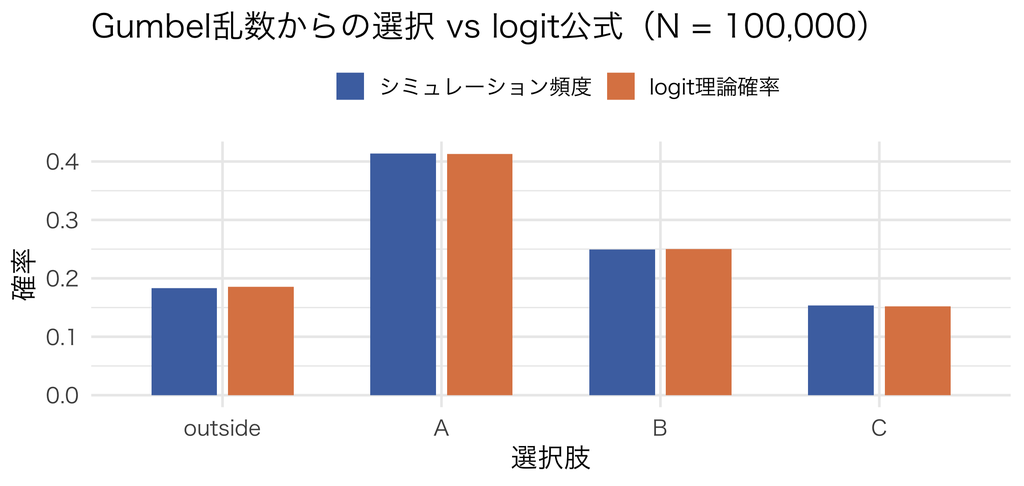

図 1

2本の棒はほぼ完全に重なる。logit公式は「魔法の数式」ではなく、**Gumbel + RUM の機械的な帰結**。

# Outside option

## 正規化は2つある

| 不変性 | 観測から区別できない変換 | 標準logitで置くもの |
| --- | --- | --- |
| **位置** | 全効用に同じ定数を足す | outsideの$v_{i0}=0$ |
| **尺度** | 全効用を同じ正の定数倍 | Gumbel誤差のscale $=1$ |

- 識別される係数は、誤差スケールに対する**相対値**
- 異なる標本・モデルの係数の絶対値を単純比較しない

## 実務の悩み：市場規模の定義

「買わない」に**誰を含めるか**：

- 棚の前を通って買わなかった人？ 来店客全員？ 商圏人口？
- ペットボトルコーヒーを買った人は「缶コーヒーを買わない」に含める？

市場規模の設定次第で outside のシェアが変わり、**価格弾力性の計算結果も変わる**。実務ではこの定義自体が分析の質を左右する。

今日は単純化して「棚の前でN人が選ぶ」という設定で進める。

# 最尤法

## 推定量とは「関数」である

計量Iの言い方：**推定量＝データをパラメータの推定値に変換する関数**

- OLS：$(X, Y) \mapsto \hat\beta = (X'X)^{-1}X'Y$
- 最尤法：**同じくデータから推定値への関数**。ただし関数の「作り方」の発想が違う

今日の課題：$v_{ij}$ の中の価格係数・属性への好みを、選択データから推定したい。

## コイン投げから始める

コインを $n$ 回投げて表が $x$ 回。表の出る確率 $p$ が未知パラメータ。

このデータが観測される確率（**尤度**）：

$$L(p) = \binom{n}{x} p^x (1-p)^{n-x}$$

最尤法のアイデア：「**今観測されたデータが得られる確率が一番高くなる $p$** を推定値として採用する」

## 対数尤度

実際には対数を取った**対数尤度**を最大化する：

$$\ell(p) = \ln L(p) = \text{const} + x \ln p + (n - x)\ln(1 - p)$$

- 対数は単調変換 → 最大化する $p$ は同じ
- 多数の観測の尤度は**積** → 対数を取れば**和**になり数値的に安定

## 対数尤度のかたち：n = 20, x = 14

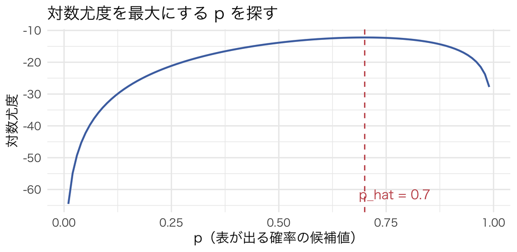

図 2

- ピークは $\hat p = x/n = 0.7$（標本比率そのもの。直感と一致）
- コインは解析解が出る。**logitは出ない → 数値的にピークを探す**

## logitの対数尤度

$y_{ij}$：消費者 $i$ が財 $j$ を選んだら1。選択確率を $s_{ij}(\theta)$ と書くと

$$\ell(\theta) = \sum_{i=1}^{N} \sum_{j=0}^{J} y_{ij} \ln s_{ij}(\theta)$$

- 「各消費者が**実際に選んだ財**の選択確率の対数」を足し合わせたもの
- 観測された選択パターンに高い確率を割り当てる $\theta$ ほど $\ell(\theta)$ が大きい

## コインからlogitへ：1人・2択で橋をかける

財1を選ぶ確率を $s_i(\theta)$、実際の選択を $y_i\in\{0,1\}$ とすると

$$L_i(\theta)=s_i(\theta)^{y_i}\{1-s_i(\theta)\}^{1-y_i}$$

| 観測 | 対数尤度への寄与 |
| --- | --- |
| $y_i=1$ | $\log s_i(\theta)$ |
| $y_i=0$ | $\log\{1-s_i(\theta)\}$ |

多項版 $\sum_j y_{ij}\log s_{ij}$ も「**実際に選んだ確率のlogだけ拾う**」式。

## うれしい性質：大域凹性

線形指数logitの対数尤度は $\theta$ について**大域的に凹**

- 収束して見つけた局所最大は大域最大
- ただし一意性には**十分なrank・完全分離なし**が必要
- 凹性は、どのアルゴリズム・初期値からも必ず収束する保証ではない

これはlogitの特権。後の回の動学的離散選択モデルなどでは、こうはいかない。

# 自作MLEでlogitを推定する

## DGP：缶コーヒー棚に戻る

N = 3,000人が、3ブランド + outside から選択。属性は**価格**と**甘さ**。

$$v_{ij} = c_j + \beta_s \cdot \mathrm{sweet}_j - \alpha \cdot \mathrm{price}_j$$

- ブランド固有の切片：$c_A = \mathrm{const}_A$、$c_B = \mathrm{const}_B$、$c_C = 0$
- outside option：$v_{i0} = 0$

outsideを0にするのは**位置正規化**。C切片を0にするのは別の実質的制約。

```r
N <- 3000
true_params <- list(const_A = 1.2, const_B = 0.6,
                    beta_sweet = 0.5, alpha_price = 0.02)
price_base <- c(130, 120, 110)   # 円
sweetness  <- c(3, 6, 5)          # 1-10スケール
```

## なぜC切片を落とすのか：rankを目で見る

sweetnessはブランド固定なので

$$\mathrm{sweet}=3D_A+6D_B+5D_C$$

- A・B・Cの全切片＋sweetを入れると完全共線
- 今の列 $(D_A,D_B,\mathrm{sweet})$ はrank 3
- C切片0は「Cの未観測ブランド魅力=0」という識別制約

市場・商品をまたいでsweetが変われば、全切片と属性係数を識別できる場合もある。

## 生成されたデータ：選択シェア

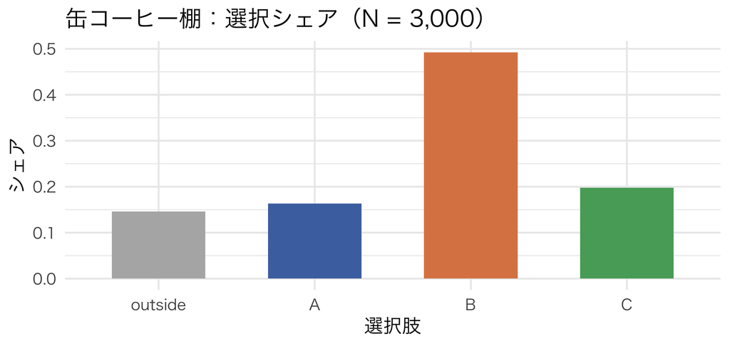

図 3

- Bが最も甘く（sweet = 6）、シェアも最大。直感的に妥当な分布
- 価格には個人ごとの変動（プロモーション・店舗差）を入れてある

## 負の対数尤度を自分で書く

```r
neg_loglik_mnl <- function(theta, X, choice) {
  n <- dim(X)[1]; J1 <- dim(X)[2]
  V <- matrix(0, nrow = n, ncol = J1)
  for (j in 1:J1) V[, j] <- X[, j, ] %*% theta
  V <- V - apply(V, 1, max)          # オーバーフロー対策（確率は不変）
  expV <- exp(V)
  denom <- rowSums(expV)
  chosen_idx <- cbind(1:n, choice + 1)
  logprob <- V[chosen_idx] - log(denom)
  -sum(logprob)
}
```

- `X` は（消費者 × 選択肢 × パラメータ）の説明変数の配列
- 数式 $\ell(\theta) = \sum_i \sum_j y_{ij} \ln s_{ij}(\theta)$ をそのまま書いただけ
- `optim()` は最小化するので**負**の対数尤度を返す

## `optim()` で最大化

```r
opt_result <- optim(
  par = c(0, 0, 0, 0),               # 中立的な初期値。収束診断は別途確認
  fn = neg_loglik_mnl,
  X = X_design, choice = choice_vec,
  method = "BFGS", hessian = TRUE
)
theta_hat <- opt_result$par
names(theta_hat) <- c("const_A", "const_B", "beta_sweet", "alpha_price")
round(theta_hat, 4)
```

```
    const_A     const_B  beta_sweet alpha_price
     1.0134      0.6537      0.4328      0.0170
```

## 真値回収の確認

|  | パラメータ | 真値 | MLE推定値 |
| --- | --- | --- | --- |
| const_A | const_A | 1.20 | 1.0134 |
| const_B | const_B | 0.60 | 0.6537 |
| beta_sweet | beta_sweet | 0.50 | 0.4328 |
| alpha_price | alpha_price | 0.02 | 0.0170 |

**真値回収（parameter recovery）**：DGPを自分で書き、真のパラメータでデータを作り、推定量がそれを復元できるか確かめる。**新しい推定量を実装したら、必ず最初にやるべき検証**。

## 推論：HessianからSEと信頼区間

正しく特定されたiid尤度なら、分散共分散行列を（負の対数尤度の）**Hessianの逆行列**で近似できる。

|  | パラメータ | 真値 | 推定値 | SE | 95%CI下限 | 95%CI上限 |
| --- | --- | --- | --- | --- | --- | --- |
| const_A | const_A | 1.20 | 1.0134 | 0.20461 | 0.6124 | 1.4145 |
| const_B | const_B | 0.60 | 0.6537 | 0.06649 | 0.5234 | 0.7840 |
| beta_sweet | beta_sweet | 0.50 | 0.4328 | 0.06888 | 0.2978 | 0.5678 |
| alpha_price | alpha_price | 0.02 | 0.0170 | 0.00310 | 0.0109 | 0.0231 |

- 真値はすべて95%信頼区間の中
- **推定値だけでなく不確実性まで報告する**——計量Iから変わらない推論の作法
- これはモデルベースSE。誤特定ならsandwich、反復選択ならcluster-robustを検討

## モンテカルロ：95%CIは本当に95%か

同じDGPからデータを引き直し、推定→CI構築を繰り返して**被覆率**を数える。

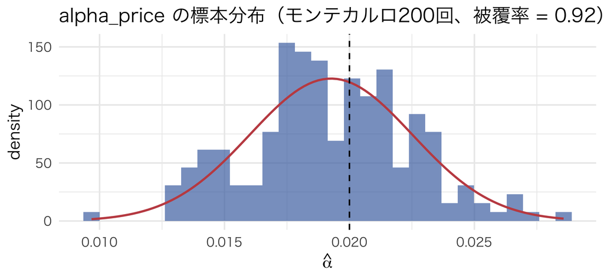

# 価格弾力性とプライシング

## 推定の先にある問い

パラメータが手に入った。次は本題：

> **Aを値上げしたら、Aのシェアはどれくらい減るか。客はどこへ流れるか。**

logitモデルなら、弾力性が**閉形式**で書ける。

$$\eta_{jj} = -\alpha \, p_j \,(1 - s_j), \qquad
\eta_{jk} = \alpha \, p_k \, s_k \quad (k \neq j)$$

- $\eta_{jj}$：自己価格弾力性（自分の値上げで自分のシェアが減る）
- $\eta_{jk}$：交差価格弾力性（他財 $k$ の値上げで自分のシェアが増える）

## 推定値で弾力性行列を計算する

弾力性行列（行 = シェアが変化する財、列 = 価格が変化する財）

|  | A | B | C |
| --- | --- | --- | --- |
| A | -1.8500 | 1.0058 | 0.3687 |
| B | 0.3596 | -1.0338 | 0.3687 |
| C | 0.3596 | 1.0058 | -1.5009 |

## この表、どこか変じゃないか？

**B列（Bの値上げ）**：$\eta_{A,B}=\eta_{C,B}$ —— **増加率**が同じ。

| 見る量 | $j\neq k$の式 | 行き先$j$で違う？ |
| --- | --- | --- |
| 交差弾力性 | $\alpha p_k s_k$ | 違わない |
| シェアポイント変化 | $\alpha s_j s_k\,dp_k$ | 元の$s_j$に比例 |

AとCへの絶対流入は同じではない。しかし「Bに似ているからAへ余分に流れる」は表現できない。

**IIA（Independence of Irrelevant Alternatives）**：logitモデルに内在する制約。財の「似ている度合い」を代替パターンに反映できない。→ **次回のテーマ**

## 価格を動かすと：シェアと収入

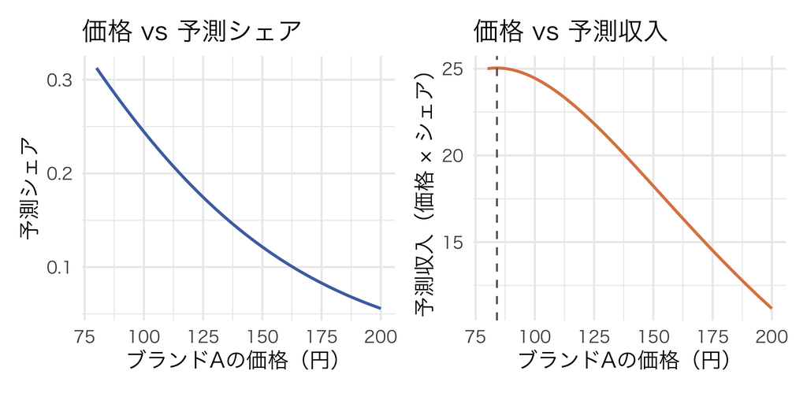

図 4

- 収入曲線に**山の頂点**＝収入を最大化する価格が現れる
- シェアの下がり方と価格の上がり方のバランスから、最適な一点が定まる

## ここが核心

- RUM：$u_{ij} = v_{ij} + \varepsilon_{ij}$、効用最大の財を選ぶ
- Gumbel仮定 → 選択確率が閉形式のlogit公式になる（シミュレーションで確認済み）
- 最尤法：「観測されたデータが最も出やすいパラメータ」を選ぶ。`optim()` で自作できる
- HessianからSE・CI。モンテカルロで被覆率を検証できる
- 弾力性は閉形式：$\eta_{jj} = -\alpha p_j(1-s_j)$、$\eta_{jk} = \alpha p_k s_k$ → プライシングに直結
- ただし**IIA**という制約つき → 次回

# まとめ

## 宿題

- `optim()` の `method` を `"Nelder-Mead"` や `"CG"` に変えて、推定値がどう変わるか（変わらないか）確認する
- 生成AIに「なぜ離散選択モデルはGumbel分布を使うのか、正規分布ではダメなのか」と聞いて、今日の説明と比べる
- **coding課題は `assignment2.qmd`**：動画配信サービスのプラン選択を題材に、DGP→自作MLE→推論→反実仮想を自分の手で実装

## 次回予告：logitの限界に切り込む

- 今日の弾力性表で見た違和感の正体＝**IIA**を正面から扱う
- 代替性を柔軟にする **nested logit**
- 価格が需要ショックと相関する**内生性**と、**Berry反転 + 操作変数法**
- 缶コーヒーの例が、さらに複雑になって再登場する

**Reading**：上武ほか (2025)『実証ビジネス・エコノミクス』第2章、Train (2009) Chapters 2-3